## **S4532362**

# Assessment 2

```r
## install packages once via console using - install.packages("tidyverse")
library(tidyverse)   # load tidyverse library
library(skimr)       # load skimr library
library(janitor)     # load janitor library
```

```r
library(ggplot2)     # load ggplot library
library(knitr)       # load knitr library
library(randomForest)# load randomForest library
```

### Insert an R chunk and create a dataset variable called `data`

```r
# use readr function to import the and read data from csv
# save data into dataset called "data"
data <- readr::read_csv('https://raw.githubusercontent.com/rfordatascience/tidytuesday/master/data/2018/2018-11-20/thanksgiving_meals.csv')
```

### Part 2: Data Wrangling and visualization

### 1. Display the first 10 rows of the dataset using `kable()` function

```r
# use kable function to read dataset and display first 10 rows and the first 5 variables
kable((data[1:10, 1:5]))
```

| id | celebrate | main_dish | main_dish_other | main_prep |
| --- | --- | --- | --- | --- |
| 4337954960 | Yes | Turkey | NA | Baked |
| 4337951949 | Yes | Turkey | NA | Baked |
| 4337935621 | Yes | Turkey | NA | Roasted |
| 4337933040 | Yes | Turkey | NA | Baked |
| 4337931983 | Yes | Tofurkey | NA | Baked |
| 4337929779 | Yes | Turkey | NA | Roasted |
| 4337924420 | Yes | Turkey | NA | Baked |
| 4337916002 | Yes | Turkey | NA | Baked |
| 4337914977 | Yes | Turkey | NA | Roasted |
| 4337899817 | Yes | Other (please specify) | Turkey and Ham | Baked |

### 2. Using `skim()` display the summary of variables

#### **Main observations:**

- Data missing from most variables and will need to be removed before using in later and calculations and visualizations
- There are a large number of side, pie and dessert variables

```r
# pipe dataset into skim function to summarize whole dataset
data %>%
  skim()
```

Data summary

| Name | Piped data |
| --- | --- |
| Number of rows | 1058 |
| Number of columns | 65 |
| _______________________ |  |
| Column type frequency: |  |
| character | 64 |
| numeric | 1 |
| ________________________ |  |
| Group variables | None |

**Variable type: character**

| skim_variable | n_missing | complete_rate | min | max | empty | n_unique | whitespace |
| --- | --- | --- | --- | --- | --- | --- | --- |
| celebrate | 0 | 1.00 | 2 | 3 | 0 | 2 | 0 |
| main_dish | 84 | 0.92 | 6 | 22 | 0 | 8 | 0 |
| main_dish_other | 1023 | 0.03 | 4 | 85 | 0 | 32 | 0 |
| main_prep | 84 | 0.92 | 5 | 22 | 0 | 5 | 0 |
| main_prep_other | 1007 | 0.05 | 1 | 33 | 0 | 32 | 0 |
| stuffing | 84 | 0.92 | 4 | 22 | 0 | 4 | 0 |
| stuffing_other | 1022 | 0.03 | 4 | 46 | 0 | 29 | 0 |
| cranberry | 84 | 0.92 | 4 | 22 | 0 | 4 | 0 |
| cranberry_other | 1033 | 0.02 | 3 | 61 | 0 | 24 | 0 |
| gravy | 84 | 0.92 | 2 | 3 | 0 | 2 | 0 |
| side1 | 903 | 0.15 | 15 | 15 | 0 | 1 | 0 |
| side2 | 816 | 0.23 | 7 | 7 | 0 | 1 | 0 |
| side3 | 970 | 0.08 | 11 | 11 | 0 | 1 | 0 |
| side4 | 594 | 0.44 | 4 | 4 | 0 | 1 | 0 |
| side5 | 823 | 0.22 | 9 | 9 | 0 | 1 | 0 |
| side6 | 843 | 0.20 | 11 | 11 | 0 | 1 | 0 |
| side7 | 372 | 0.65 | 32 | 32 | 0 | 1 | 0 |
| side8 | 852 | 0.19 | 19 | 19 | 0 | 1 | 0 |
| side9 | 241 | 0.77 | 15 | 15 | 0 | 1 | 0 |
| side10 | 292 | 0.72 | 14 | 14 | 0 | 1 | 0 |
| side11 | 887 | 0.16 | 6 | 6 | 0 | 1 | 0 |
| side12 | 849 | 0.20 | 15 | 15 | 0 | 1 | 0 |
| side13 | 427 | 0.60 | 27 | 27 | 0 | 1 | 0 |
| side14 | 947 | 0.10 | 22 | 22 | 0 | 1 | 0 |
| side15 | 947 | 0.10 | 4 | 78 | 0 | 89 | 0 |
| pie1 | 544 | 0.49 | 5 | 5 | 0 | 1 | 0 |
| pie2 | 1023 | 0.03 | 10 | 10 | 0 | 1 | 0 |
| pie3 | 945 | 0.11 | 6 | 6 | 0 | 1 | 0 |
| pie4 | 925 | 0.13 | 9 | 9 | 0 | 1 | 0 |
| pie5 | 1022 | 0.03 | 13 | 13 | 0 | 1 | 0 |
| pie6 | 1019 | 0.04 | 8 | 8 | 0 | 1 | 0 |
| pie7 | 1024 | 0.03 | 5 | 5 | 0 | 1 | 0 |
| pie8 | 716 | 0.32 | 5 | 5 | 0 | 1 | 0 |
| pie9 | 329 | 0.69 | 7 | 7 | 0 | 1 | 0 |
| pie10 | 906 | 0.14 | 12 | 12 | 0 | 1 | 0 |
| pie11 | 1018 | 0.04 | 4 | 4 | 0 | 1 | 0 |
| pie12 | 987 | 0.07 | 22 | 22 | 0 | 1 | 0 |
| pie13 | 987 | 0.07 | 5 | 46 | 0 | 61 | 0 |
| dessert1 | 948 | 0.10 | 13 | 13 | 0 | 1 | 0 |
| dessert2 | 1042 | 0.02 | 8 | 8 | 0 | 1 | 0 |
| dessert3 | 930 | 0.12 | 8 | 8 | 0 | 1 | 0 |
| dessert4 | 986 | 0.07 | 11 | 11 | 0 | 1 | 0 |
| dessert5 | 867 | 0.18 | 10 | 10 | 0 | 1 | 0 |
| dessert6 | 854 | 0.19 | 7 | 7 | 0 | 1 | 0 |
| dessert7 | 1015 | 0.04 | 5 | 5 | 0 | 1 | 0 |
| dessert8 | 792 | 0.25 | 9 | 9 | 0 | 1 | 0 |
| dessert9 | 955 | 0.10 | 13 | 13 | 0 | 1 | 0 |
| dessert10 | 763 | 0.28 | 4 | 4 | 0 | 1 | 0 |
| dessert11 | 924 | 0.13 | 22 | 22 | 0 | 1 | 0 |
| dessert12 | 924 | 0.13 | 3 | 59 | 0 | 92 | 0 |
| prayer | 99 | 0.91 | 2 | 3 | 0 | 2 | 0 |
| travel | 107 | 0.90 | 59 | 80 | 0 | 4 | 0 |
| watch_program | 556 | 0.47 | 13 | 13 | 0 | 1 | 0 |
| kids_table_age | 107 | 0.90 | 2 | 13 | 0 | 12 | 0 |
| hometown_friends | 107 | 0.90 | 2 | 3 | 0 | 2 | 0 |
| friendsgiving | 107 | 0.90 | 2 | 3 | 0 | 2 | 0 |
| black_friday | 107 | 0.90 | 2 | 3 | 0 | 2 | 0 |
| work_retail | 107 | 0.90 | 2 | 3 | 0 | 2 | 0 |
| work_black_friday | 988 | 0.07 | 2 | 13 | 0 | 3 | 0 |
| community_type | 110 | 0.90 | 5 | 8 | 0 | 3 | 0 |
| age | 33 | 0.97 | 3 | 7 | 0 | 4 | 0 |
| gender | 33 | 0.97 | 4 | 6 | 0 | 2 | 0 |
| family_income | 33 | 0.97 | 12 | 20 | 0 | 11 | 0 |
| us_region | 59 | 0.94 | 7 | 18 | 0 | 9 | 0 |

**Variable type: numeric**

| skim_variable | n_missing | complete_rate | mean | sd | p0 | p25 | p50 | p75 | p100 | hist |
| --- | --- | --- | --- | --- | --- | --- | --- | --- | --- | --- |
| id | 0 | 1 | 4336731188 | 493783.4 | 4335894916 | 4336339486 | 4336796628 | 4337012140 | 4337954960 | ▅▃▇▂▂ |

### 3. Use `fct_reorder` and `parse_number` functions to create a factor variable `family_income`

```r
# Pipe dataset into mutate and use fct_reorder to reorder factor levels by sorting with variable family_income and save back to dataset
# Use parse_number function to drop any non-numeric characters before or after the first number in variable family_income
data <- data %>%
  mutate(family_income = fct_reorder(family_income, parse_number(family_income, na = c("Prefer not to answer"))))
```

### 4. What is the number of people who celebrate?

#### **Main observations:**

- 980 people celebrate thanksgiving

```r
# Pipe dataset into count function and count variable celebrate (total how many yes / no answers) then
# pipe into arrange function and arrange rows by variables celebrate in descending order then
# pipe into kabble() function to create simple table with output
data %>%
  count(celebrate) %>%
  arrange(-n) %>%
  kable()
```

| celebrate | n |
| --- | --- |
| Yes | 980 |
| No | 78 |

### 5. What are categories and insights for each main dish served and the method it is prepared?

#### **Main observations:**

- Main dish categories include: Turkey, Ham/Pork, Roast beef, Tofurkey, Chicken, Turducken and Other/I dont know.
- Main prep categories include: Baked, Roasted, Fried and Other/I dont know.

```r
# pipe dataset into filter function and remove all na obs from variable main_dish and main_prep then
# pipe into group_by function and select variable main_dish, main_prep and main_prep_other then
# pipe into count function and count variable main_dish and sort in descending order then
# pipe into kabble() function to create simple table with output
data %>%
  filter(!is.na(main_dish) & !is.na(main_prep)) %>%
  group_by(main_dish, main_prep, main_prep_other) %>%
  count(main_dish, sort=TRUE) %>%
  kable()
```

| main_dish | main_prep | main_prep_other | n |
| --- | --- | --- | --- |
| Turkey | Baked | NA | 422 |
| Turkey | Roasted | NA | 351 |
| Turkey | Fried | NA | 41 |
| Ham/Pork | Baked | NA | 22 |
| Other (please specify) | Baked | NA | 16 |
| Tofurkey | Baked | NA | 14 |
| Turkey | I don’t know | NA | 11 |
| Turkey | Other (please specify) | Smoked | 7 |
| Ham/Pork | Roasted | NA | 5 |
| Other (please specify) | Roasted | NA | 5 |
| Roast beef | Roasted | NA | 5 |
| Chicken | Baked | NA | 4 |
| Chicken | Roasted | NA | 4 |
| Tofurkey | Roasted | NA | 4 |
| Turkey | Other (please specify) | Grilled | 4 |
| Turkey | Other (please specify) | smoked | 4 |
| I don’t know | I don’t know | NA | 3 |
| Other (please specify) | Other (please specify) | grilled | 3 |
| Roast beef | Baked | NA | 3 |
| Turducken | Roasted | NA | 3 |
| Chicken | Fried | NA | 2 |
| Chicken | Other (please specify) | Grilled | 2 |
| Roast beef | Fried | NA | 2 |
| Ham/Pork | I don’t know | NA | 1 |
| Ham/Pork | Other (please specify) | smoked | 1 |
| I don’t know | Fried | NA | 1 |
| I don’t know | Roasted | NA | 1 |
| Other (please specify) | Fried | NA | 1 |
| Other (please specify) | I don’t know | NA | 1 |
| Other (please specify) | Other (please specify) | always different | 1 |
| Other (please specify) | Other (please specify) | Barbeque | 1 |
| Other (please specify) | Other (please specify) | Broiled | 1 |
| Other (please specify) | Other (please specify) | like soup | 1 |
| Other (please specify) | Other (please specify) | Restaurant with various choices. | 1 |
| Other (please specify) | Other (please specify) | Smoked | 1 |
| Other (please specify) | Other (please specify) | stovetop | 1 |
| Other (please specify) | Other (please specify) | Varies | 1 |
| Other (please specify) | Other (please specify) | Varies as per above | 1 |
| Roast beef | Other (please specify) | Slow cooked | 1 |
| Tofurkey | I don’t know | NA | 1 |
| Tofurkey | Other (please specify) | various ways | 1 |
| Turkey | Other (please specify) | 1 fried 1 roasted | 1 |
| Turkey | Other (please specify) | baked, grilled, fried | 1 |
| Turkey | Other (please specify) | Barbecue | 1 |
| Turkey | Other (please specify) | BBQ’d | 1 |
| Turkey | Other (please specify) | Cooked in bourbon and then smokes | 1 |
| Turkey | Other (please specify) | Cooked on a Weber Charcoal Grill | 1 |
| Turkey | Other (please specify) | fried | 1 |
| Turkey | Other (please specify) | Fried and one baked | 1 |
| Turkey | Other (please specify) | grilled | 1 |
| Turkey | Other (please specify) | Grilled on the Weber | 1 |
| Turkey | Other (please specify) | Having a Smoked Turkey this year | 1 |
| Turkey | Other (please specify) | O | 1 |
| Turkey | Other (please specify) | on the grill | 1 |
| Turkey | Other (please specify) | Ronco | 1 |
| Turkey | Other (please specify) | Rotisserie | 1 |
| Turkey | Other (please specify) | roulade | 1 |
| Turkey | Other (please specify) | store smoked | 1 |
| Turkey | Other (please specify) | Try a new technique yearly. | 1 |
| Turkey | Other (please specify) | We eat out | 1 |

### 6. Create 3 different data viz showing insights for main dish served and the method.

#### **Data visualisation 1**

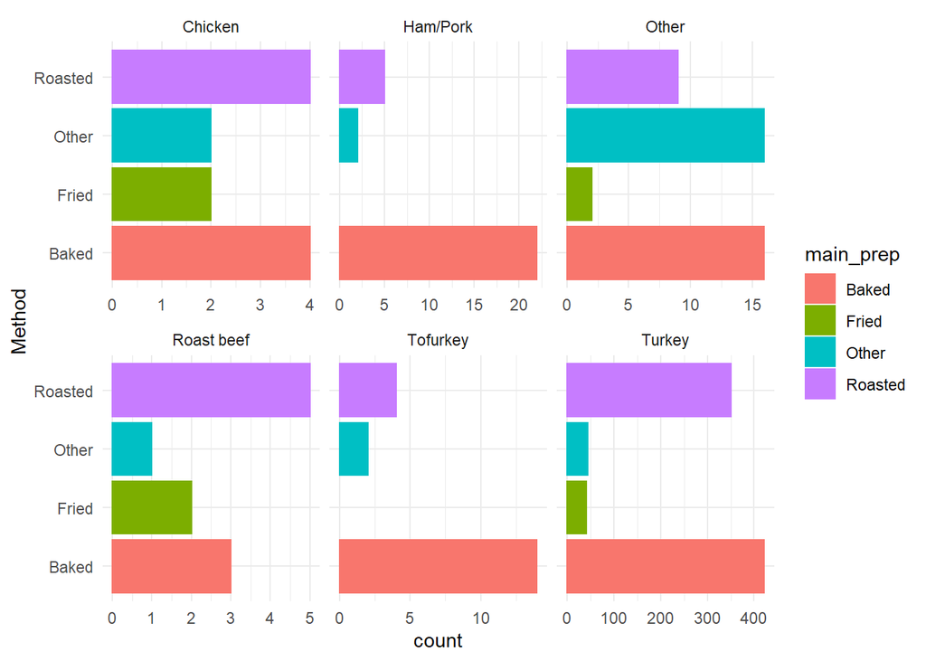

```r
# Data visualisation 1
# pipe dataset into filter function and remove all na obs from variable main_dish then
# pipe into mutate, select var main_dish and use fct_collapse to collapse 3 x obs into manually defined group "Other" then
# pipe into mutate, select var main_prep and use fct_collapse to collapse 3 x obs into manually defined group "Other" then
# pipe into ggplot, select discrete variable main_prep and use variable main_prep as color and fill in data viz then
# add geom_bar and use facet_wrap to create 4 plots for variable main_dish and allow x scale to vary across rows then
# add a label to the x axis and use coord_flip so that horizontal becomes vertical, and vertical, horizontal then
# add theme "theme_minimal" which controls all non-data display
data %>%
  filter(!is.na(main_dish) & !is.na(main_prep)) %>%
  mutate(main_dish = fct_collapse(main_dish, Other = c("I don't know", "Other (please specify)", "Turducken"))) %>%
  mutate(main_prep = fct_collapse(main_prep, Other = c("I don't know", "Other (please specify)"))) %>%
  ggplot(aes(main_prep, color=main_prep,fill = main_prep))+
  geom_bar()+ # add Bar charts using geom_bar
  facet_wrap(vars(main_dish), ncol = 3, scales = "free_x")+
  labs(x = "Method")+
  coord_flip() +
  theme_minimal()
```

#### *Data visualisation 2*

- Shows the most prevalent preparation methods according to dish served
- Most prevalent preparation methods on thanksgiving are:
1. Baked
2. Roasted
3. Other
4. Fried

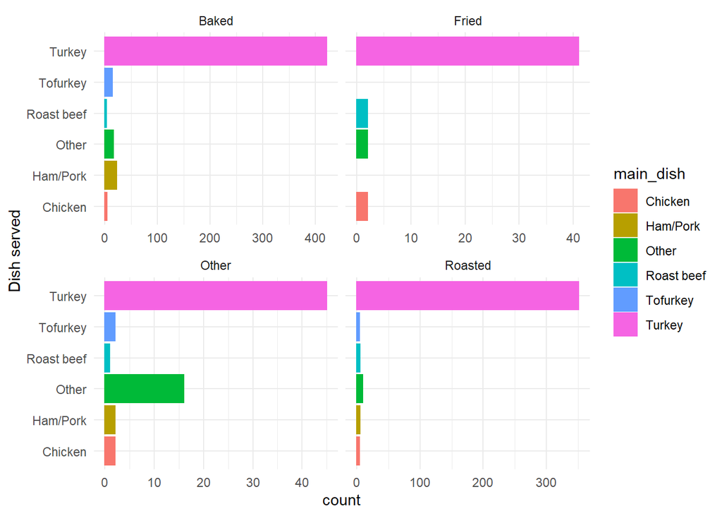

```r
# Data visualisation 2
# pipe dataset into filter function and remove all na obs from variable main_dish then
# pipe into mutate, select var main_dish and use fct_collapse to collapse 3 x obs into manually defined group "Other" then
# pipe into mutate, select var main_prep and use fct_collapse to collapse 3 x obs into manually defined group "Other" then
# pipe into ggplot, select discrete variable main_prep and use variable main_prep as color and fill in data viz then
# add geom_bar and use facet_wrap to create 2 plots for variable main_prep and allow x scale to vary across rows then
# add a label to the x axis and use coord_flip so that horizontal becomes vertical, and vertical, horizontal then
# add theme "theme_minimal" which controls all non-data display
data %>%
  filter(!is.na(main_dish) & !is.na(main_prep)) %>%
  mutate(main_dish = fct_collapse(main_dish, Other = c("I don't know", "Other (please specify)", "Turducken"))) %>%
  mutate(main_prep = fct_collapse(main_prep, Other = c("I don't know", "Other (please specify)"))) %>%
  ggplot(aes(main_dish,color=main_dish,fill = main_dish))+
  geom_bar()+
  facet_wrap(vars(main_prep), ncol = 2, scales = "free_x") +
  labs(x = "Dish served") +
  coord_flip()+
  theme_minimal()
```

#### *Data visualisation 3*

- Shows the most prevalent preparation methods for Turkey by count
- Most prevalent preparation methods for Turkey are:
1. Baked
2. Roasted
3. Other

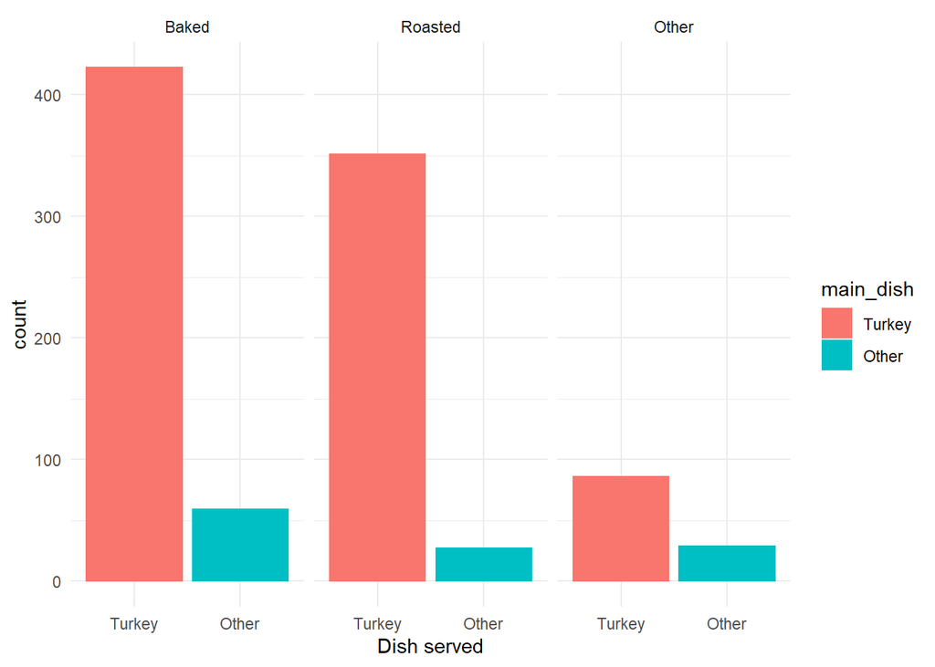

```r
# Data viz 3
# pipe dataset into filter function and remove all na obs from variable main_dish and main_prep then
# pipe into mutate, select main_dish, use fct_lump to lumps together the least frequent levels, ensuring that "other" is still the smallest
# pipe into mutate, select var main_prep, use fct_lump to lumps together the least frequent levels, ensuring that "other" is still the smallest
# pipe into ggplot, select discrete variable main_dish and use variable main_dish as color and fill in data viz then
# add geom_bar and use facet_wrap to create 3 plots for variable main_prep then
# add a label to the x axis and use theme function to remove legend then
# add theme "theme_minimal" which controls all non-data display
data %>%
  filter(!is.na(main_dish) & !is.na(main_prep)) %>%
  mutate(main_dish = fct_lump_lowfreq(main_dish)) %>% # Use fct_lump to lump together all the small main_dish
  mutate(main_prep = fct_lump_lowfreq(main_prep)) %>% # Use fct_lump to lump together all the small main_prep
  ggplot(aes(main_dish,color=main_dish,fill = main_dish))+
  geom_bar()+
  facet_wrap(vars(main_prep), ncol = 3)+
  labs(x = "Dish served") +
  theme(legend.position = "none")+
  theme_minimal()
```

### 7. How many use cranberry sauce? How many use gravy?

#### **Main observations:**

- 828 people use cranberry
- 892 people use gravy

#### Count of cranberry sauce use

```r
# pipe dataset into filter function and remove all na obs from variable main_dish then
# pipe into mutate, select var cranberry and use fct_collapse to collapse 2 x obs into manually defined groups "Yes / No" then
# pipe into count function and count variable cranberry and sort in descending order then
# pipe into kabble() function to create simple table with output
data %>%
  filter(!is.na(main_dish)) %>%
  mutate(cranberry = fct_collapse(cranberry,
                                  Yes = c("Homemade","Canned", "Other (please specify)"),
                                  No = c("None"))) %>%
  count(cranberry, sort = TRUE) %>%
  kable()
```

| cranberry | n |
| --- | --- |
| Yes | 828 |
| No | 146 |

#### Count of gravy use

```r
# pipe dataset into filter function and remove all na obs from variable main_dish then
# pipe into count function and count variable gravy and sort in descending order then
# pipe into kabble() function to create simple table with output
data %>%
  filter(!is.na(main_dish)) %>%
  count(gravy, sort = TRUE) %>%
  kable()
```

| gravy | n |
| --- | --- |
| Yes | 892 |
| No | 82 |

### 8. What is the distribution of those who celebrate across income ranges

#### **Main observation:**

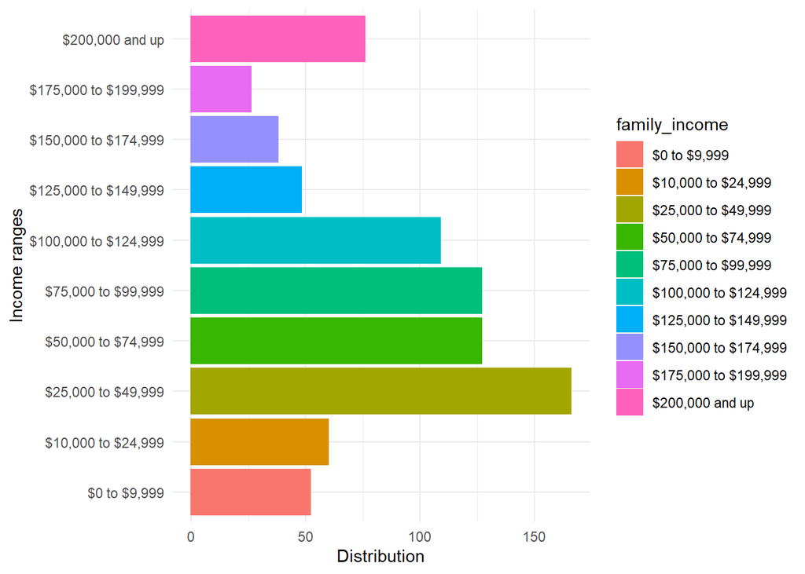

```r
# pipe dataset into filter function and select celebrate = yes, remove "prefer not to say" obs from variable family_income then
# pipe into ggplot, select variable family_income and use variable family_income as color and fill in data viz then
# add geom_bar and use labs function to add a label to the x and y axis then
# use coord_flip so that horizontal becomes vertical, and vertical, horizontal then
# use theme function to remove legend
# add theme "theme_minimal" which controls all non-data display
data %>%
  filter((celebrate=="Yes") & family_income != "Prefer not to answer") %>%
  ggplot(aes(family_income,color=family_income,fill = family_income))+
  geom_bar()+
  labs(x = "Income ranges", y = "Distribution") +
  coord_flip()+
  theme(legend.position = "none") +
  theme_minimal()
```

### 10. Use the following code to create a new data

##### Create new dataset that contans the different groups of type side dish by id

```r
# pipe dataset into select function and select id and any obs that stats with side. pie, dessert then
# pipe into select function to remove variables side15, pie13, desert12 then
# pipe into gather function to gather into key-values pairs by id then and create new columns "type" and  "vaule" then
# pipe dataset into filter function and remove all na, "none" and "Other not to say" obs then
# pipe into mutate function and use str_remove function to remove ""\\d+" from type column
# create new dataset "new_data" to assign output back into
new_data <- data %>%
  select(id, starts_with("side"),
         starts_with("pie"),
         starts_with("dessert")) %>%
  select(-side15, -pie13, -dessert12) %>%
  gather(type, value, -id) %>%
  filter(!is.na(value),
         !value %in% c("None", "Other (please specify)")) %>%
  mutate(type = str_remove(type, "\\d+"))
```

### 11. Intall package `widyr` and use `pairwise_cor()` function

#### **Main observation:**

- Cookies and Brownies have the highest correlation (0.41)

```r
# download and install "widyr" package from CRAN repositories then
# install packages once via console using - install.packages("widyr")
# load library "widyr" using library(widyr)
# pipe "new_data" into pairwise_cor function to identify groups of highly correlated items "value and id" and sort in descending order

# install.packages("widyr")
library(widyr)
new_data %>% pairwise_cor(value, id, sort = TRUE)
```

```
## # A tibble: 992 x 3
##    item1               item2               correlation
##    <chr>               <chr>                     <dbl>
##  1 Cookies             Brownies                  0.411
##  2 Brownies            Cookies                   0.411
##  3 Sweet Potato        Macaroni and cheese       0.365
##  4 Macaroni and cheese Sweet Potato              0.365
##  5 Rolls/biscuits      Mashed potatoes           0.341
##  6 Mashed potatoes     Rolls/biscuits            0.341
##  7 Peach cobbler       Sweet Potato              0.339
##  8 Sweet Potato        Peach cobbler             0.339
##  9 Pumpkin             Mashed potatoes           0.290
## 10 Mashed potatoes     Pumpkin                   0.290
## # ... with 982 more rows
```

### 13. Use `lm()` or `randomForest()` function to build a model that predict a family income based on data in the dataset.

#### **Main observation:** What America eats on thanksgiving is a poor indicator to predict family income.

1. Model 3 showed the highest relationship (~9%) between age, work and comunity type based variables and family income.
2. Model 2 showed a (~7.5%) relationship between age and location based variables and family income.
3. Model 1 showed a (~6%) relationship between food based variables and family income

##### Remove any non-numeric characters and na obs from variable “family_income” and save to new variable “family_income_num”.

```r
# pipe dataset into mutate and use parse_number function to drop any non-numeric characters before or after the first number in variable family_income and create new column family_income_num to save output then
# pipe dataset into filter function and remove all na obs from variable family_income_num then
# create new dataset "data1" to assign output back into data1
data1 <- data %>%
  mutate(family_income_num=parse_number(as.character(family_income))) %>%
  filter(!is.na(family_income_num))
```

##### Model 1: Food based regression model

- Shows a low relationship (~6%) between food based variables and family income.
- Based on a forest of trees using random inputs from celebrate, main_dish, main_prep, and age.

```r
# download and install "randomForest" package from CRAN repositories then
# install packages once via console using - install.packages("randomForest")
# use randomForest function to predict correlation of celebrate, main_dish, main_prep, age to family_income_num and remove "na" obs from data
randomForest(family_income_num~celebrate+main_dish+main_prep+age,data=data1, na.action=na.omit)
```

```
##
## Call:
##  randomForest(formula = family_income_num ~ celebrate + main_dish +      main_prep + age, data = data1, na.action = na.omit)
##                Type of random forest: regression
##                      Number of trees: 500
## No. of variables tried at each split: 1
##
##           Mean of squared residuals: 3276883042
##                     % Var explained: 5.97
```

- Shows a low relationship (~7.5%) between age and location based variables and family income.
- Based on a forest of trees using random inputs from age, community_type, us_region.

```r
# use randomForest function to predict correlation of age, community_type and us_region to family_income_num and remove "na" obs from data
randomForest(family_income_num~age+community_type+us_region,data=data1, na.action=na.omit)
```

```
##
## Call:
##  randomForest(formula = family_income_num ~ age + community_type +      us_region, data = data1, na.action = na.omit)
##                Type of random forest: regression
##                      Number of trees: 500
## No. of variables tried at each split: 1
##
##           Mean of squared residuals: 3204207291
##                     % Var explained: 7.46
```

##### Model 3: Work type and community based regression model

- Shows a low relationship (~9%) between age, work and comunity type based variables and family income.
- Based on a forest of trees using random inputs from age, work_retail and community_type.

```r
# use randomForest function to predict correlation of age, community_type and us_region to family_income_num and remove "na" obs from data
randomForest(family_income_num~age+work_retail+community_type,data=data1, na.action=na.omit)
```

```
##
## Call:
##  randomForest(formula = family_income_num ~ age + work_retail +      community_type, data = data1, na.action = na.omit)
##                Type of random forest: regression
##                      Number of trees: 500
## No. of variables tried at each split: 1
##
##           Mean of squared residuals: 3172052292
##                     % Var explained: 8.98
```